# Assignment 1.2

Tiana Lee

# All Packages Needed

These are all the packages needed that were not started in Dockerfile

```r
if (!requireNamespace("GEOquery", quietly = TRUE)) {
  BiocManager::install("GEOquery")
}
```

```
## Setting options('download.file.method.GEOquery'='auto')
```

```
## Setting options('GEOquery.inmemory.gpl'=FALSE)
```

```r
library(GEOquery)
if (!requireNamespace("dplyr", quietly = TRUE)) {
  tidyr::install("dplyr")
}

library(dplyr)
if(!requireNamespace("limma", quietly = TRUE)) {
  install.packages("limma")
}
```

# initialize variables

We are starting with what the geo_id is and the extra information that is attached to the geo_id

```r
geo_id <- "GSE242722"
gse <- getGEO(geo_id, GSEMatrix=FALSE)
```

```
## Reading file....
```

```
## Parsing....
```

[output not shown]

[output not shown]

[output not shown]

[output not shown]

[output not shown]

[output not shown]

[output not shown]

[output not shown]

[output not shown]

[output not shown]

[output not shown]

[output not shown]

[output not shown]

[output not shown]

```r
gse@header$summary
```

```
## [1] "Clinical data show SARS-CoV-2 infection causes activation of host inflammatory antiviral response, including the type I interferon pathway and the expression of many inflammatory cytokines, as well as the infiltration of neutrophils and macrophages. It has been hypothesized that the overt ho…
```

# get expression data

We first will download the expression data and make sure that it isnt downloaded multiple times.

```r
geo_filename <- getGEOSuppFiles(geo_id, fetch_files = FALSE)

geo_filename$fname
```

```
## [1] "GSE242722_Raw_counts_of_sequencing_reads_for_genes.csv.gz"
```

```r
data_filename <- geo_filename$fname[1]

download_geofile <- file.path(getwd()) #download and stores files

missing_files <- geo_filename$fname[!unlist(
  lapply(geo_filename$fname, FUN=function(x){
    file.exists(
      file.path(download_geofile, geo_id, x))}))]

# only one supplemental file
```

# Reading the data

We read and format the data.

```r
some_data <- read.csv(file.path(download_geofile, geo_id, data_filename),
                       header = TRUE,
                       check.names = FALSE)

dim(some_data)
```

```
## [1] 57500    14
```

```r
colnames(some_data)[1:14]
```

```
##  [1] "ID"        "HSAEP1"    "HSAEP2"    "HSAEU1"    "HSAEU2"    "NHBED1"
##  [7] "NHBED2"    "NHBEP1"    "NHBEP2"    "NHBEU1"    "NHBEU2"    "NHBEU3"
## [13] "NHBEU4"    "Gene.name"
```

```r
pt1 <- data.frame(some_data$ID)
pt2 <- data.frame(some_data[, 6:14])
some_exp <- cbind(pt1, pt2)
```

# Collecting additional annotations

This is where we get the additional gse information which it tells you the characteristics and titles of the samples used

```r
list_of_samples <- gse@gsms
sample_type <- do.call(rbind,
                       lapply(list_of_samples,
                              FUN=function(x){
                                c(x@header$title,
                                  x@header$characteristics_ch1)
                              }))
sample_type
```

```
##            [,1]
## GSM7767639 "NHBE, UI-4"
## GSM7767640 "NHBE, UI-3"
## GSM7767641 "NHBE, UI-2"
## GSM7767642 "NHBE, UI-1"
## GSM7767643 "NHBE, pSARS2-2"
## GSM7767644 "NHBE, pSARS2-1"
## GSM7767645 "NHBE, Delta-2"
## GSM7767646 "NHBE, Delta-1"
## GSM7767647 "HSAEC, UI-6"
## GSM7767648 "HSAEC, UI-5"
## GSM7767649 "HSAEC, pSARS2-2"
## GSM7767650 "HSAEC, pSARS2-1"
##            [,2]
## GSM7767639 "cell type: normal human bronchial/tracheal epithelial"
## GSM7767640 "cell type: normal human bronchial/tracheal epithelial"
## GSM7767641 "cell type: normal human bronchial/tracheal epithelial"
## GSM7767642 "cell type: normal human bronchial/tracheal epithelial"
## GSM7767643 "cell type: normal human bronchial/tracheal epithelial"
## GSM7767644 "cell type: normal human bronchial/tracheal epithelial"
## GSM7767645 "cell type: normal human bronchial/tracheal epithelial"
## GSM7767646 "cell type: normal human bronchial/tracheal epithelial"
## GSM7767647 "cell type: human small airway epithelial cells"
## GSM7767648 "cell type: human small airway epithelial cells"
## GSM7767649 "cell type: human small airway epithelial cells"
## GSM7767650 "cell type: human small airway epithelial cells"
##            [,3]
## GSM7767639 "treatment: mock infection"
## GSM7767640 "treatment: mock infection"
## GSM7767641 "treatment: mock infection"
## GSM7767642 "treatment: mock infection"
## GSM7767643 "treatment: SARS-CoV-2 spike pseudotyped lentiviruses"
## GSM7767644 "treatment: SARS-CoV-2 spike pseudotyped lentiviruses"
## GSM7767645 "treatment: SARS-CoV-2 Delta variant"
## GSM7767646 "treatment: SARS-CoV-2 Delta variant"
## GSM7767647 "treatment: mock infection"
## GSM7767648 "treatment: mock infection"
## GSM7767649 "treatment: SARS-CoV-2 spike pseudotyped lentiviruses"
## GSM7767650 "treatment: SARS-CoV-2 spike pseudotyped lentiviruses"
```

# Cleaning up descriptions

Since the discriptions can be overwhelming and we are also not using all of the datasets, this is where we get rid of what we dont want

```r
colnames(sample_type) <- c("title", "cell type","treatment given")

sample_type[,1] <- gsub(sample_type[,1],
                               pattern = "NHBE, ",
                               replacement = "")
sample_type[,2] <- gsub(sample_type[,2],
                                   pattern = "cell type: ",
                                   replacement = "")
sample_type[,3] <- gsub(sample_type[,3],
                                         pattern = "treatment: ",
                                         replacement = "")

sample_type <- as.data.frame(sample_type[1:8,])

sample_type
```

|  | title | cell type | treatment given |
| --- | --- | --- | --- |
| GSM7767639 | UI-4 | normal human bronchial/tracheal epithelial | mock infection |
| GSM7767640 | UI-3 | normal human bronchial/tracheal epithelial | mock infection |
| GSM7767641 | UI-2 | normal human bronchial/tracheal epithelial | mock infection |
| GSM7767642 | UI-1 | normal human bronchial/tracheal epithelial | mock infection |
| GSM7767643 | pSARS2-2 | normal human bronchial/tracheal epithelial | SARS-CoV-2 spike pseudotyped lentiviruses |
| GSM7767644 | pSARS2-1 | normal human bronchial/tracheal epithelial | SARS-CoV-2 spike pseudotyped lentiviruses |
| GSM7767645 | Delta-2 | normal human bronchial/tracheal epithelial | SARS-CoV-2 Delta variant |
| GSM7767646 | Delta-1 | normal human bronchial/tracheal epithelial | SARS-CoV-2 Delta variant |

```r
kableExtra::kable(sample_type[1:8,], format = "html")
```

|  | title | cell type | treatment given |
| --- | --- | --- | --- |
| GSM7767639 | UI-4 | normal human bronchial/tracheal epithelial | mock infection |
| GSM7767640 | UI-3 | normal human bronchial/tracheal epithelial | mock infection |
| GSM7767641 | UI-2 | normal human bronchial/tracheal epithelial | mock infection |
| GSM7767642 | UI-1 | normal human bronchial/tracheal epithelial | mock infection |
| GSM7767643 | pSARS2-2 | normal human bronchial/tracheal epithelial | SARS-CoV-2 spike pseudotyped lentiviruses |
| GSM7767644 | pSARS2-1 | normal human bronchial/tracheal epithelial | SARS-CoV-2 spike pseudotyped lentiviruses |
| GSM7767645 | Delta-2 | normal human bronchial/tracheal epithelial | SARS-CoV-2 Delta variant |
| GSM7767646 | Delta-1 | normal human bronchial/tracheal epithelial | SARS-CoV-2 Delta variant |

# removing datasets that have weak or no expression and information

Since not all of the data is useful to us, we want to know what is expressing at an acceptable statical level. Additionally, our downstream analysis will be skewed if there is missing information since the script will not know what to do with it.

```r
# calculate the counts per million using the edgeR package function cpm
cpms <- edgeR::cpm(some_exp[, 2:9])

# now drop the genes with low counts, n = 2 since there are 2 replicates of each type of variant
keep <- rowSums(cpms > 1) >= 2

filtered_data <- some_exp[keep,]

# number of unimportant genes dropped:
num_removed <-  dim(some_exp)[1] - dim(filtered_data)[1]

num_removed
```

```
## [1] 42299
```

```r
# get rid of all of the genes that are NA
clean_data <- dplyr::filter(filtered_data, !is.na(filtered_data$Gene.name))
clean_data
```

| some_data.ID | NHBED1 | NHBED2 | NHBEP1 | NHBEP2 | NHBEU1 | NHBEU2 | NHBEU3 | NHBEU4 | Gene.name |
| --- | --- | --- | --- | --- | --- | --- | --- | --- | --- |
| ENSG00000227232 | 34 | 42 | 94 | 77 | 122 | 83 | 80 | 94 | WASH7P |
| ENSG00000268903 | 2 | 5 | 10 | 12 | 23 | 15 | 14 | 25 | AL627309.6 |
| ENSG00000279457 | 53 | 71 | 91 | 102 | 125 | 66 | 109 | 159 | FO538757.1 |
| ENSG00000225630 | 79 | 64 | 114 | 107 | 90 | 132 | 78 | 121 | MTND2P28 |
| ENSG00000237973 | 261 | 194 | 307 | 270 | 273 | 306 | 185 | 193 | MTCO1P12 |
| ENSG00000248527 | 3677 | 2967 | 3564 | 3418 | 2855 | 3491 | 3122 | 7543 | MTATP6P1 |
| ENSG00000228327 | 1 | 11 | 53 | 44 | 84 | 61 | 8 | 53 | AL669831.1 |
| ENSG00000228794 | 111 | 171 | 189 | 147 | 271 | 245 | 153 | 157 | LINC01128 |
| ENSG00000187634 | 176 | 194 | 65 | 77 | 30 | 73 | 86 | 55 | SAMD11 |
| ENSG00000188976 | 3322 | 3538 | 3024 | 2991 | 1896 | 3063 | 3121 | 1665 | NOC2L |

[output cut: 9990 more lines]

```r
# get rid of all duplicated genes
clean_data <- clean_data %>% dplyr::filter(duplicated(Gene.name) == FALSE)

# percentage of missing genes
(dim(clean_data)/dim(filtered_data)) * 100
```

```
## [1]  99.79607 100.00000
```

# Mapping genes

We map all the genes to make sure that the data looks how we want it to look and also it helps us know if any of the genes were duplicated. We see that there are 15170 genes that are still unique after all of the cleaning

```r
mapped_genes <- data.frame(row.names = clean_data$Gene.name)

mapped_genes <- cbind(mapped_genes,clean_data$NHBED1, clean_data$NHBED2, clean_data$NHBEP1, clean_data$NHBEP2, clean_data$NHBEU1, clean_data$NHBEU2, clean_data$NHBEU3, clean_data$NHBEU4)

mapped_genes
```

|  | clean_data$NHBED1 | clean_data$NHBED2 | clean_data$NHBEP1 | clean_data$NHBEP2 | clean_data$NHBEU1 | clean_data$NHBEU2 | clean_data$NHBEU3 | clean_data$NHBEU4 |
| --- | --- | --- | --- | --- | --- | --- | --- | --- |
| WASH7P | 34 | 42 | 94 | 77 | 122 | 83 | 80 | 94 |
| AL627309.6 | 2 | 5 | 10 | 12 | 23 | 15 | 14 | 25 |
| FO538757.1 | 53 | 71 | 91 | 102 | 125 | 66 | 109 | 159 |
| MTND2P28 | 79 | 64 | 114 | 107 | 90 | 132 | 78 | 121 |
| MTCO1P12 | 261 | 194 | 307 | 270 | 273 | 306 | 185 | 193 |
| MTATP6P1 | 3677 | 2967 | 3564 | 3418 | 2855 | 3491 | 3122 | 7543 |
| AL669831.1 | 1 | 11 | 53 | 44 | 84 | 61 | 8 | 53 |
| LINC01128 | 111 | 171 | 189 | 147 | 271 | 245 | 153 | 157 |
| SAMD11 | 176 | 194 | 65 | 77 | 30 | 73 | 86 | 55 |
| NOC2L | 3322 | 3538 | 3024 | 2991 | 1896 | 3063 | 3121 | 1665 |

[output cut: 9990 more lines]

```r
nrow(mapped_genes)
```

```
## [1] 15170
```

# Normalization

We normalize so that we can compare genes to each other without worry about the different samples and preps.

```r
clean_data_matrix <- as.matrix(mapped_genes)
rownames(clean_data_matrix) <- rownames(mapped_genes)
d = edgeR::DGEList(counts=clean_data_matrix)
d = edgeR::calcNormFactors(d)
normalized_counts <- edgeR::cpm(d)

d
```

```
## An object of class "DGEList"
## $counts
##            clean_data$NHBED1 clean_data$NHBED2 clean_data$NHBEP1
## WASH7P                    34                42                94
## AL627309.6                 2                 5                10
## FO538757.1                53                71                91
## MTND2P28                  79                64               114
## MTCO1P12                 261               194               307
##            clean_data$NHBEP2 clean_data$NHBEU1 clean_data$NHBEU2
## WASH7P                    77               122                83
## AL627309.6                12                23                15
## FO538757.1               102               125                66
## MTND2P28                 107                90               132
## MTCO1P12                 270               273               306
##            clean_data$NHBEU3 clean_data$NHBEU4
## WASH7P                    80                94
## AL627309.6                14                25
## FO538757.1               109               159
## MTND2P28                  78               121
## MTCO1P12                 185               193
## 15165 more rows ...
##
## $samples
##                   group lib.size norm.factors
## clean_data$NHBED1     1 17748703    0.9388209
## clean_data$NHBED2     1 19138953    1.0859802
## clean_data$NHBEP1     1 22426456    1.0069504
## clean_data$NHBEP2     1 22400564    1.0097321
## clean_data$NHBEU1     1 19723399    1.0879823
## clean_data$NHBEU2     1 20696073    1.0214137
## clean_data$NHBEU3     1 23288380    0.8338337
## clean_data$NHBEU4     1 23605027    1.0410658
```

# Estimating Dispersion

We estimate dispersion so that you can see how much deviation you have from the mean. This is used in negative binomial models where the probability is due to the no of failures.

```r
model_design <- model.matrix(~sample_type$title)
d <- edgeR::estimateDisp(d, model_design)
norm_counts <- edgeR::cpm(d)

norm_counts[1:20, ]
```

```
##            clean_data$NHBED1 clean_data$NHBED2 clean_data$NHBEP1
## WASH7P            2.04046684         2.0207342         4.1625467
## AL627309.6        0.12002746         0.2405636         0.4428241
## FO538757.1        3.18072772         3.4160031         4.0296995
## MTND2P28          4.74108472         3.0792141         5.0481950
## MTCO1P12         15.66358368         9.3338676        13.5947005
## MTATP6P1        220.67048739       142.7504397       157.8225169
## AL669831.1        0.06001373         0.5292399         2.3469678
## LINC01128         6.66152410         8.2272751         8.3693759
## SAMD11           10.56241658         9.3338676         2.8783568
## NOC2L           199.36561303       170.2228027       133.9100144
## KLHL17           10.86248524        12.4611944        11.0263206
## PLEKHN1           5.70130441         9.0451913        21.9640764
## PERM1             2.34053549         2.5499742         6.9523387
## HES4              7.02160648         6.2546536         8.5907880
## ISG15            81.25859122        55.1371769        31.6176423
## AGRN            283.32482213       327.8881856       685.2260458
## AL390719.1        1.14026088         0.4811272         0.7528010
## RNF223            0.06001373         0.1443382         0.8413658
## C1orf159         11.16255389         8.4197260         8.3250935
## AL390719.2        0.24005492         0.9622544         1.1070603
##            clean_data$NHBEP2 clean_data$NHBEU1 clean_data$NHBEU2
## WASH7P             3.4042825          5.685337         3.9263453
## AL627309.6         0.5305375          1.071826         0.7095805
## FO538757.1         4.5095691          5.825141         3.1221541
## MTND2P28           4.7306264          4.194101         6.2443081
## MTCO1P12          11.9370946         12.722107        14.4754415
## MTATP6P1         151.1147756        133.046214       165.1430275
## AL669831.1         1.9453043          3.914495         2.8856272
## LINC01128          6.4990848         12.628905        11.5898143
## SAMD11             3.4042825          1.398034         3.4532916
## NOC2L            132.2364815         88.355734       144.8963315
## KLHL17            13.3960729         11.230871        14.9484952
## PLEKHN1           22.6804798         21.343316        17.7395117
## PERM1              7.4717370          8.061995         7.2377208
## HES4               9.1075611         21.762726         5.7712545
## ISG15             36.1649756          5.918343         6.6700564
## AGRN             653.9317280        689.417052       717.8116009
## AL390719.1         0.9726522          1.677641         1.0407180
## RNF223             1.2379209          1.584438         1.1353287
```

[output cut: 8 more lines]

```
## MTATP6P1         160.7734005       306.9456237
## AL669831.1         0.4119754         2.1567172
## LINC01128          7.8790296         6.3887661
## SAMD11             4.4287356         2.2381028
## NOC2L            160.7219036        67.7534752
## KLHL17            18.1269177        13.4693095
## PLEKHN1           18.8478746        14.8528639
## PERM1              5.3556802         5.8190672
## HES4              21.5772117        12.1671406
## ISG15             31.8250998        16.3584967
## AGRN             781.8263186       363.9968983
## AL390719.1         1.3389201         1.7090967
## RNF223             0.6179631         0.2441567
## C1orf159          16.5820099         9.1558750
## AL390719.2         0.6179631         1.1393978
```

# BOXPLOT

## Unnormalized

reference: 4 [github wiki]

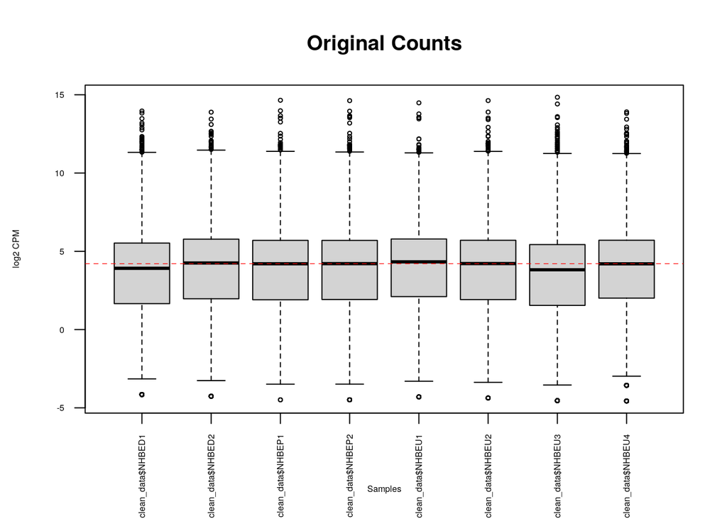

```r
data2plot <- log2(edgeR::cpm(mapped_genes))
boxplot(data2plot, xlab = "Samples", ylab = "log2 CPM",
        las = 2, cex = 0.5, cex.lab = 0.5,
        cex.axis = 0.5, main = "Original Counts")
abline(h = median(apply(data2plot, 2, median)),
       col = "red",
       lwd = 0.6,
       lty = "dashed")
```

## Normalized

reference: 4 [github wiki]

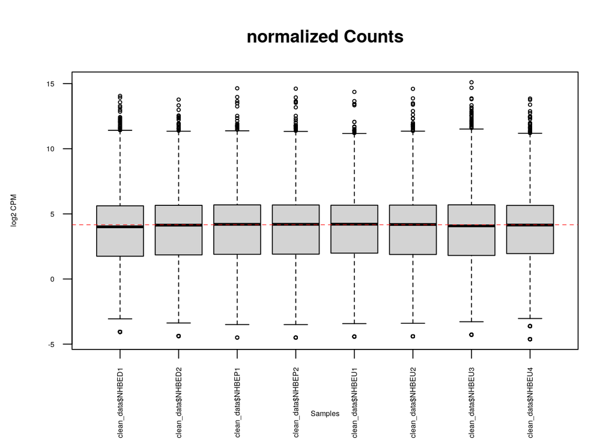

```r
norm_data2plot <- log2(norm_counts)
boxplot(norm_data2plot, xlab = "Samples", ylab = "log2 CPM",
        las = 2, cex = 0.5, cex.lab = 0.5,
        cex.axis = 0.5, main = "normalized Counts")
abline(h = median(apply(norm_data2plot, 2, median)),
       col = "red",
       lwd = 0.6,
       lty = "dashed")
```

# MEAN VARIANCE RELATIONSHIP

reference: 4 [github wiki]

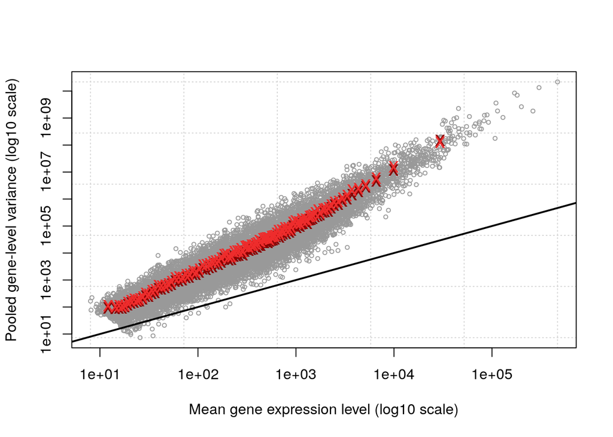

```r
edgeR::plotMeanVar(d, show.raw.vars = TRUE,
                   show.tagwise.vars = TRUE,
                   NBline = TRUE,
                   show.ave.raw.vars = TRUE,
                   show.binned.common.disp.vars = TRUE)
```

# DENSITY PLOT

## Unnormalized

reference: 4 [github wiki]

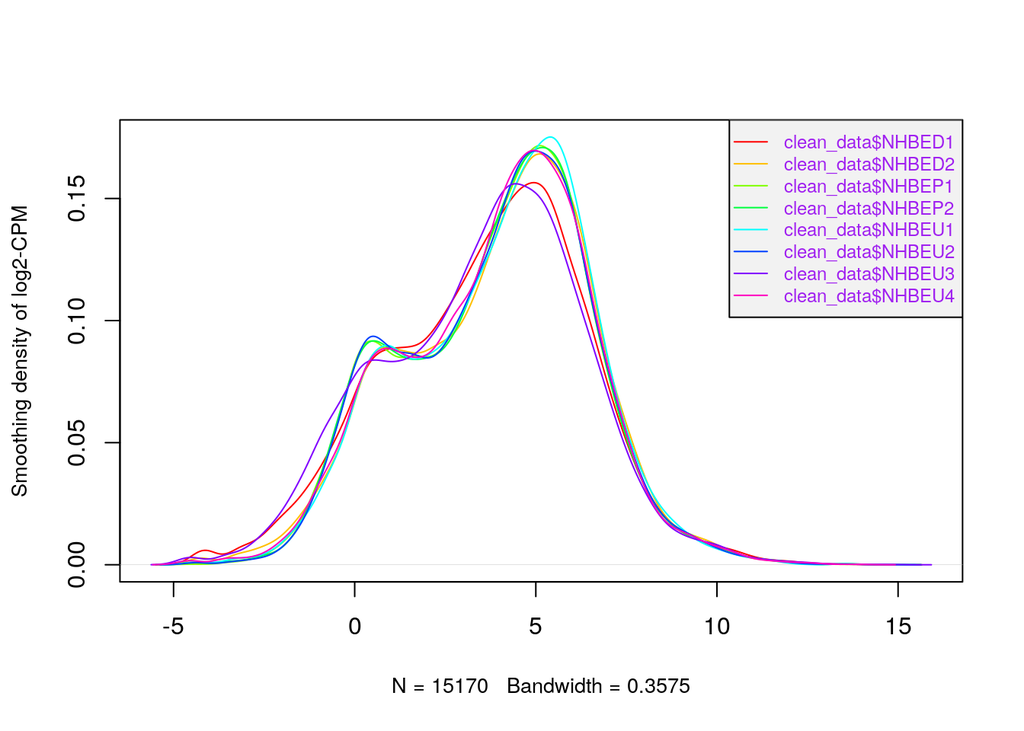

```r
counts_density <- apply(log2(edgeR::cpm(mapped_genes)),
                        2,
                        density)

xlim <- 0; ylim <- 0
for (i in 1:length(counts_density)) {
  xlim <- range(c(xlim, counts_density[[i]]$x));
  ylim <- range(c(ylim, counts_density[[i]]$y))
}
cols <- rainbow(length(counts_density))
ltys <- rep(1, length(counts_density))

#plotting first line
plot(counts_density[[1]], xlim=xlim, ylim=ylim, type="n",
     ylab="Smoothing density of log2-CPM", main="", cex.lab = 0.85)

#plotting rest of lines
for (i in 1:length(counts_density)) {
  lines(counts_density[[i]], col=cols[i], lty=ltys[i])
}

#creating legend
legend("topright", colnames(data2plot),
       col=cols, lty=ltys, cex=0.75,
       border ="blue",  text.col = "purple",
       merge = TRUE, bg = "gray95")
```

## Normalized

reference: 4 [github wiki]

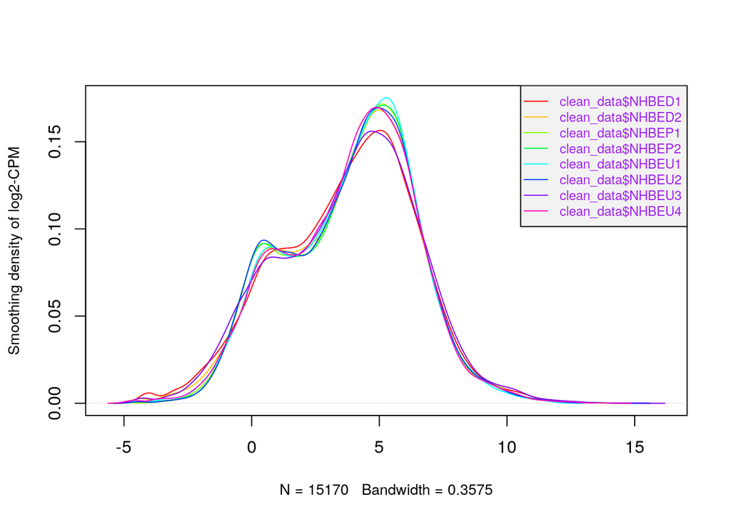

```r
norm_counts_density <- apply(log2(norm_counts), 2, density)

xlim <- 0; ylim <- 0
for (i in 1:length(norm_counts_density)) {
  xlim <- range(c(xlim, norm_counts_density[[i]]$x));
  ylim <- range(c(ylim, norm_counts_density[[i]]$y))
}
cols <- rainbow(length(norm_counts_density))
ltys <- rep(1, length(norm_counts_density))

#plotting the first line
plot(norm_counts_density[[1]], xlim=xlim, ylim=ylim, type="n",
     ylab="Smoothing density of log2-CPM", main="", cex.lab = 0.85)

#plotting rest of the lines
for (i in 1:length(norm_counts_density)) {
  lines(norm_counts_density[[i]], col=cols[i], lty=ltys[i])
}

legend("topright", colnames(data2plot),
       col=cols, lty=ltys, cex=0.75,
       border ="blue",  text.col = "purple",
       merge = TRUE, bg = "gray95")
```

# Interpreting and Documenting Data

- is the dataset of interest to you? **Significance of paper within [https://github.com/bcb420-2024/Tiana_Lee/wiki/3.1-Assignment-1#choosing-an-expression-data-set CHOOSING A DATASET]
- What are the control and test conditions of the dataset?
  - The control is the uninfected (NHBEU#) vs the test conditions of (NHBEP# OR NHBED#)
- How many samples in each of the conditions of your dataset?
  - There are 2 samples of each of the test conditions and 4 of the uninfected conditions.
- Were there expression values that were not unique for specific genes? How did you handle these?
  - Yes, there were expression values that were not unique for a specific gene. We did this by [Chunk 7: removing datasets that have weak or no expression and information of RNotebook]
- Were there expression values that could not be mapped to current HUGO symbols?
  - No, there isn’t any that we know about since the values were already mapped to HUGO symbols
- Were there any outliers in your dataset? How were they handled in the originating paper? How many outliers were removed?
  - Yes, there were outliers in the dataset. It is not mentioned how they handled it in the originating paper. Therefore, we do not know how many outliers were removed.
- How did you handle replicates?
  - I handled replicates by treating them as their own set. Then, look at them to interpret the biological significance of the dataset.
- What is the final coverage of your dataset?
  - The final coverage of the dataset is 15170

All Conclusions and interpretations are additionally in the https://github.com/bcb420-2024/Tiana_Lee/wiki/3.1-Assignment-1

# Reference

1. Odak I, Riemann L, Sandrock I, Cossmann A, Ramos GM, Hammerschmidt SI, Ritter C, Friedrichsen M, Hassan A, Dopfer-Jablonka A, Stankov MV, Weskamm LM, Addo MM, Ravens I, Willenzon S, Schimrock A, Ristenpart J, Janssen A, Barros-Martins J, Hansen G, Falk C, Behrens GMN, Förster R. Systems biology analysis reveals distinct molecular signatures associated with immune responsiveness to the BNT162b COVID-19 vaccine. EBioMedicine. 2024 Jan;99:104947. doi: 10.1016/j.ebiom.2023.104947. Epub 2023 Dec 30. PMID: 38160529; PMCID: PMC10792461.
2. Davis S, Meltzer P (2007). “GEOquery: a bridge between the Gene Expression Omnibus (GEO) and BioConductor.” Bioinformatics, 14, 1846–1847.
3. Erickson R, Huang C, Allen C, Ireland J, Roth G, Zou Z, Lu J, Lafont BAP, Garza NL, Brumbaugh B, Zhao M, Suzuki M, Olano L, Brzostowski J, Fischer ER, Twigg HL 3rd, Johnson RF, Sun PD. SARS-CoV-2 infection of human lung epithelial cells induces TMPRSS-mediated acute fibrin deposition. Nat Commun. 2023 Oct 11;14(1):6380. doi: 10.1038/s41467-023-42140-6. PMID: 37821447; PMCID: PMC10567911.
4. https://bcb420-2020.github.io/student_JoelleJee/A1.html
5. Landau WM, Liu P. Dispersion estimation and its effect on test performance in RNA-seq data analysis: a simulation-based comparison of methods. PLoS One. 2013 Dec 9;8(12):e81415. doi: 10.1371/journal.pone.0081415. PMID: 24349066; PMCID: PMC3857202.

All References are in https://github.com/bcb420-2024/Tiana_Lee/wiki/3.1-Assignment-1